# Welcome to Introduction to Bayesian Statistics (MATH 429/629)

AG Schissler

## III. Frequentist vs. Bayesian (10 min)

(modified from Bolstad & Curran Ch.1, p.6)

Frequentist (classical) approach to statistics

- parameters, the numerical characterics of a population (think of them as **targets of learning**), as fixed but unknown constants.
- probabilities as *always* long-run relative frequency.
- Statistical procedures are judged how often things occur in an infinite number of repetitions of the experiment

Bayesian approach to statistics

- We model parameters as random variables since we are uncertain about their true value.
- The basic rules of probability are used **directly** to make statistical inferences about the parameters (it’s how we **update** our beliefs about uncertain quantities in light of data)
- Probability statements must be interpreted as a “degree of belief” (not hypothetical long-run relative frequency)
- Each person can have his/her own prior beliefs before (and must be able to formalize that belief as a probability distribution)

## II. Our community (20 min)

### Students:

Undergraduate and graduate students (mostly) in math, engineering, and computer science

#### Activity

Please introduce yourself to your neighbor(s):

1. Name (what you liked to be called)
2. Major
3. Professional goals
4. (Appropriate) personal interests

Let’s go around the room and everyone please introduce your partner(s).

### Grader: Diana Powers, MS

Diana, please introduce yourself.

### Instructor: A. Grant Schissler, PhD

- background: 6 years of high schools teaching, 4 years at higher Ed teaching
- education: BS in Applied Math, MS in Applied Stat, PhD in Statistics
- research interests: Developing stats methods for personalized medicine, statistical computing, Bayesian modeling, clustering, high dimensional data, large scale hypothesis testing
- other interests: hiking, tennis, running, ukulele, games

### Reciprocal interview

#### Questions for you:

1. What is Bayesian statistics (your own definition, don’t look anything up at this time)?
2. What are your goals for the course?
3. What is your best outcome imagined for the course?
4. What is your worst outcome imagined for the course?
5. What is the most likely outcome imagined for the course?
6. What can I do to help you learn best?

#### Questions for me/Diana

Please, please, ask anything on your mind (about the class) — anxieties, hopes, policies, procedures, anything.

### Take away

Assume good will among everyone here. **Ask Questions** and **Work Together** — these are the most important reasons for class time.

## III. Course expectations and learning outcomes (25 min)

### Some thoughts

- Focus is on core Bayesian statistical ideas and techniques, both computational and analytic.
- Class will be cumulative, so keep up with the material and assignments!
- There will be both online and paper assignments.
- I’ll use a variety of instructional in-class activites: lecture, group activities, more involved “lab” assignments, and student-led presentations.

### Expectations for time committment

In-class activities require 2.5 hours/week.

```r
inclass_dat <- read_excel("~/OneDrive - University of Nevada, Reno/Teaching/Bayes_course/git_public/course_materials/Spring2019_inclass_schedule.xlsx")
## str(inclass_dat)

sum_dat <- inclass_dat %>%
  group_by(Activity) %>%
  summarise(Minutes = sum(Minutes), n = n())

sum_dat$Percent <- sum_dat$Minutes/sum(sum_dat$Minutes) * 100

sum_dat
```

```
## # A tibble: 4 x 4
##   Activity       Minutes     n Percent
##   <chr>            <dbl> <int>   <dbl>
## 1 Activity-based     710    37    35.1
## 2 Closing            235    24    11.6
## 3 Lecture            825    39    40.7
## 4 Solo work          255    27    12.6
```

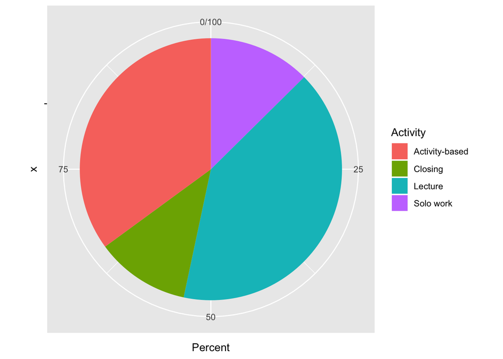

```r
bp <- ggplot(sum_dat, aes(x="", y=Percent, fill=Activity)) +
    geom_bar(width = 1, stat = "identity")
## bp

pie <- bp + coord_polar("y", start=0)
pie
```

Out-of-class activities depend on many individual factors. I’d regard these expected durations to be on the low end (it will likely take a bit longer).

```r
outclass_dat <- read_excel("~/OneDrive - University of Nevada, Reno/Teaching/Bayes_course/git_public/course_materials/Spring2019_outside_class_schedule.xlsx")
## str(outclass_dat)

## drop 'None' category
outclass_dat <- outclass_dat[outclass_dat$Activity != "None",]
outclass_dat$Activity <- factor(outclass_dat$Activity)

sum_dat <- outclass_dat %>%
  group_by(Activity) %>%
  summarise(Minutes = sum(Minutes), n = n())

sum_dat$Percent <- sum_dat$Minutes/sum(sum_dat$Minutes) * 100

sum_dat
```

```
## # A tibble: 6 x 4
##   Activity           Minutes     n Percent
##   <fct>                <dbl> <int>   <dbl>
## 1 Computer exercises     480     7   11.0
## 2 Final exam             240     1    5.48
## 3 Hand exercises         900    11   20.5
## 4 Online module          720     3   16.4
## 5 Reading               1560    13   35.6
## 6 Test prep              480     4   11.0
```

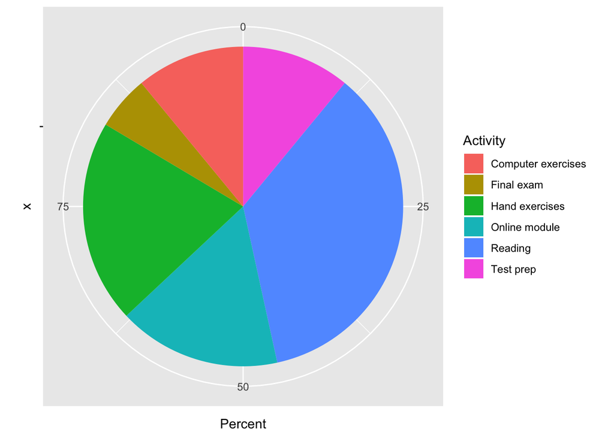

```r
## sum(sum_dat$Percent)

bp <- ggplot(sum_dat, aes(x="", y=Percent, fill=Activity)) +
    geom_bar(width = 1, stat = "identity")

pie <- bp + coord_polar("y", start=0)
pie
```

```r
## weekly expectation
sum_dat <- outclass_dat %>% group_by(Week) %>% summarise(Minutes = sum(Minutes), n = n())
cat(mean(sum_dat$Minutes)/60, "hours")
```

```
## 4.866667 hours
```

### Syllabus

[syllabus](https://github.com/grizant/Intro_Bayes_Course/blob/develop/syllabus/STAT446-646-Intro-to-Bayesian-Statistics-syllabus.pdf)

Think-pair-share

1. Please read the syllabus and list/mark 5 most important things.
2. Pair up and share your thought with your neighbor(s).
3. Share with the whole group.

### Detailed learning outcomes

[learning outcomes](https://github.com/grizant/Intro_Bayes_Course/blob/develop/course_materials/Intro-to-Bayesian-Statistics_learning_outcomes.pdf)

You can always ask, “How does this activity relate to the learning outcomes?”.

### Point-based grading system

Points are aligned with my valuation of the learning outcomes according to this matrix.

Intro_Bayes_Course_course_assessment_plan.xlsx

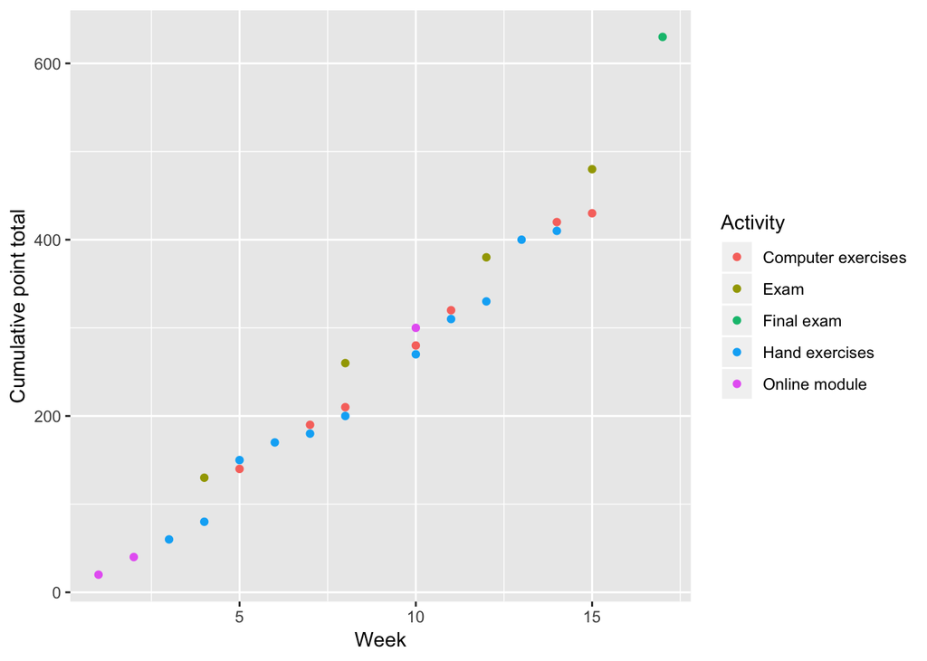

```r
points_dat <- read_excel("~/OneDrive - University of Nevada, Reno/Teaching/Bayes_course/git_public/course_materials/Spring2019_points_time.xlsx")
## str(outclass_dat)

## scatterplot
sp <- ggplot(points_dat, aes(x=Week, y=cumsum(Points), color=Activity)) + geom_point() + labs(y="Cumulative point total")
sp
```

### Course resources

#### Website

Let’s tour the website:

[course website](http://www.grantschissler.com/teaching/SP19/STAT429/).

#### Canvas (WebCampus)

- Course announcements
- Official assignments and due dates
- Gradebook management
- Secure file submissions
- Secure file sharing
- Another way to message the instructor

#### DataCamp for online modules

[datacamp.com](https://www.datacamp.com/home)

Only three modules assigned, but DataCamp has a wealth of tutorials to supplement any gaps in your preparation or to accelerate your learning.

#### Term project

629 students are required to complete a term project with my guidance. More on this soon.

#### Github

https://github.com/grizant/Intro_Bayes_Course/tree/develop

## V. Closing (5 min). 3-2-1

- 3 next actions you need to take
- 2 things you learned
- 1 friend you made (you can count me if you like ;) )

Share with the class, not the friend part if it’s embarrassing to say…